# PML Prj

Prakhar

June 27, 2018

## Executive Summary

Using devices such as Jawbone Up, Nike FuelBand, and Fitbit it is now possible to collect a large amount of data about personal activity relatively inexpensively. One thing that people regularly do is quantify how much of a particular activity they do, but they rarely quantify how well they do it. In this project, your goal will be to use data from accelerometers on the belt, forearm, arm, and dumbell of 6 participants. The goal of your project is to predict the manner in which they did the exercise. This is the “classe” variable in the training set.

The grading is done based on Classe variable which takes 5 values A,B,C,D,E in the decreasing order of exercise quality.

```r
#~~~~~~~~Set the working directory ~~~~~~~~~~~~~~~~~~~~~~~~~~~~~~~~~~~~~~~~~~~~~~~~~~~~~~~~#
setwd("C:/Working Directory/Office/Data Science/Coursera/Practical Machine Learning")
#~~~~~~~~~~~~~~~~~~~~~~~~~~~~~~~~~~~~~~~~~~~~~~~~~~~~~~~~~~~~~~~~~~~~~~~~~~~~~~~~~~~~~~~~~~#


#~~~Download the files from the url and store them in training and testing data frame~~~#

url_train <- "https://d396qusza40orc.cloudfront.net/predmachlearn/pml-training.csv"
url_test <- "https://d396qusza40orc.cloudfront.net/predmachlearn/pml-testing.csv"

destfile_train <- "pml-training.csv"
destfile_test <- "pml-testing.csv"

training <- download.file(url = url_train,destfile = destfile_train)
testing <- download.file(url = url_test, destfile = destfile_test)
```

```r
library(caret)
library(dplyr)
library(randomForest)
library(rpart)
```

```r
training_data <- read.csv(destfile_train, na.strings = c("NA","","#DIV/0!"))
validation_data <- read.csv(destfile_test, na.strings = c("NA","","#DIV/0!"))

head(training_data)
names(training_data)
head(validation_data)
names(validation_data)
```

Remove the variables which have more than 50% NA, blanks and #DIV/0! strings.

```r
training_clean <- training_data
rmcol <- NULL

for(i in 1:160){

  nas <-  sum(is.na(training_clean[,i]))
  if (nas > 10000) {
    rmcol <- c(rmcol,i)   # Creare a vector of all columns which needs to be removed #
        }
    }
training_clean <- training_clean[-rmcol]
train_data <- training_clean
validation_data <-  validation_data[-rmcol]
dim(train_data)
```

```
## [1] 19622    60
```

```r
dim(validation_data)
```

```
## [1] 20 60
```

```r
validation_data <- select(validation_data,-problem_id)
dim(validation_data)
```

```
## [1] 20 59
```

```r
names(validation_data)
```

```
##  [1] "X"                    "user_name"            "raw_timestamp_part_1"
##  [4] "raw_timestamp_part_2" "cvtd_timestamp"       "new_window"
##  [7] "num_window"           "roll_belt"            "pitch_belt"
## [10] "yaw_belt"             "total_accel_belt"     "gyros_belt_x"
## [13] "gyros_belt_y"         "gyros_belt_z"         "accel_belt_x"
## [16] "accel_belt_y"         "accel_belt_z"         "magnet_belt_x"
## [19] "magnet_belt_y"        "magnet_belt_z"        "roll_arm"
## [22] "pitch_arm"            "yaw_arm"              "total_accel_arm"
## [25] "gyros_arm_x"          "gyros_arm_y"          "gyros_arm_z"
## [28] "accel_arm_x"          "accel_arm_y"          "accel_arm_z"
## [31] "magnet_arm_x"         "magnet_arm_y"         "magnet_arm_z"
## [34] "roll_dumbbell"        "pitch_dumbbell"       "yaw_dumbbell"
## [37] "total_accel_dumbbell" "gyros_dumbbell_x"     "gyros_dumbbell_y"
## [40] "gyros_dumbbell_z"     "accel_dumbbell_x"     "accel_dumbbell_y"
## [43] "accel_dumbbell_z"     "magnet_dumbbell_x"    "magnet_dumbbell_y"
## [46] "magnet_dumbbell_z"    "roll_forearm"         "pitch_forearm"
## [49] "yaw_forearm"          "total_accel_forearm"  "gyros_forearm_x"
## [52] "gyros_forearm_y"      "gyros_forearm_z"      "accel_forearm_x"
## [55] "accel_forearm_y"      "accel_forearm_z"      "magnet_forearm_x"
## [58] "magnet_forearm_y"     "magnet_forearm_z"
```

```r
#levels(validation_data$cvtd_timestamp) <- levels(train_data$cvtd_timestamp)
#levels(validation_data$new_window) <- levels(train_data$new_window)
#levels(validation_data$user_name) <- levels(train_data$user_name)

train_data <- select(train_data,-c(1:5))
validation_data <- select(validation_data,-c(1:5))
```

Split the datasets into training set and testing set to train the model. 60% for training and 40% for testing.

```r
#~~~~~~Splitting the train data into training and testing data p = 0.6 ~~~~~~#

set.seed(23456)
inTrain <- createDataPartition(y=train_data$classe, p = 0.6,list = FALSE)
mytraining <- train_data[inTrain,]
mytesting <- train_data[-inTrain,]
```

Remove any near zero variables. Only one of them has nzv TRUE which is removed.

```r
#~~~~~~ Check and remove variables which have near zero values ~~~~~#

nzvalue_train <- nearZeroVar(mytraining,saveMetrics = TRUE)
nzvalue_train
```

```
##                      freqRatio percentUnique zeroVar   nzv
## new_window           44.643411    0.01698370   FALSE  TRUE
## num_window            1.076923    7.28600543   FALSE FALSE
## roll_belt             1.093750    8.55129076   FALSE FALSE
## pitch_belt            1.068376   13.71433424   FALSE FALSE
## yaw_belt              1.024691   14.45312500   FALSE FALSE
## total_accel_belt      1.040425    0.23777174   FALSE FALSE
## gyros_belt_x          1.075426    1.07846467   FALSE FALSE
## gyros_belt_y          1.144342    0.54347826   FALSE FALSE
## gyros_belt_z          1.080722    1.36718750   FALSE FALSE
## accel_belt_x          1.070513    1.30774457   FALSE FALSE
## accel_belt_y          1.189579    1.15489130   FALSE FALSE
## accel_belt_z          1.100189    2.42017663   FALSE FALSE
## magnet_belt_x         1.022831    2.47112772   FALSE FALSE
## magnet_belt_y         1.093085    2.42017663   FALSE FALSE
## magnet_belt_z         1.062044    3.59205163   FALSE FALSE
## roll_arm             49.119048   19.69259511   FALSE FALSE
## pitch_arm            68.800000   22.25713315   FALSE FALSE
## yaw_arm              35.568966   21.22961957   FALSE FALSE
## total_accel_arm       1.029250    0.56046196   FALSE FALSE
## gyros_arm_x           1.074576    5.26494565   FALSE FALSE
## gyros_arm_y           1.472669    3.08254076   FALSE FALSE
## gyros_arm_z           1.095847    1.94463315   FALSE FALSE
## accel_arm_x           1.087379    6.42832880   FALSE FALSE
## accel_arm_y           1.285714    4.43274457   FALSE FALSE
## accel_arm_z           1.064103    6.36039402   FALSE FALSE
## magnet_arm_x          1.090909   11.12432065   FALSE FALSE
## magnet_arm_y          1.049180    7.20957880   FALSE FALSE
## magnet_arm_z          1.045455   10.54687500   FALSE FALSE
## roll_dumbbell         1.075949   87.45754076   FALSE FALSE
## pitch_dumbbell        2.316456   85.49592391   FALSE FALSE
## yaw_dumbbell          1.025974   87.00747283   FALSE FALSE
## total_accel_dumbbell  1.074755    0.35665761   FALSE FALSE
## gyros_dumbbell_x      1.010899    1.96161685   FALSE FALSE
## gyros_dumbbell_y      1.248571    2.18240489   FALSE FALSE
## gyros_dumbbell_z      1.033613    1.64741848   FALSE FALSE
## accel_dumbbell_x      1.004975    3.43070652   FALSE FALSE
## accel_dumbbell_y      1.135714    3.84680707   FALSE FALSE
## accel_dumbbell_z      1.123188    3.37126359   FALSE FALSE
## magnet_dumbbell_x     1.229167    8.74660326   FALSE FALSE
## magnet_dumbbell_y     1.078947    6.92934783   FALSE FALSE
## magnet_dumbbell_z     1.026087    5.57914402   FALSE FALSE
## roll_forearm         11.061611   14.81827446   FALSE FALSE
## pitch_forearm        58.325000   20.88994565   FALSE FALSE
## yaw_forearm          15.546667   13.98607337   FALSE FALSE
## total_accel_forearm   1.154362    0.58593750   FALSE FALSE
## gyros_forearm_x       1.029508    2.36922554   FALSE FALSE
## gyros_forearm_y       1.063348    6.08016304   FALSE FALSE
## gyros_forearm_z       1.120567    2.39470109   FALSE FALSE
## accel_forearm_x       1.054545    6.62364130   FALSE FALSE
## accel_forearm_y       1.065574    8.21161685   FALSE FALSE
## accel_forearm_z       1.093750    4.61956522   FALSE FALSE
## magnet_forearm_x      1.086957   12.06691576   FALSE FALSE
## magnet_forearm_y      1.057692   15.21739130   FALSE FALSE
## magnet_forearm_z      1.026316   13.31521739   FALSE FALSE
## classe                1.469065    0.04245924   FALSE FALSE
```

```r
mytraining <- mytraining[,nzvalue_train$nzv==FALSE]
dim(mytraining)
```

```
## [1] 11776    54
```

```r
nzvalue_test <- nearZeroVar(mytesting,saveMetrics = TRUE)
mytesting <- mytesting[,nzvalue_test$nzv==FALSE]
dim(mytesting)
```

```
## [1] 7846   54
```

Below we experiment with three different machine learning algorithms - Random Forest, Linear Discriminant Analysis and Classificatiin Trees using rpart.

```r
#~~~~~~~~~~~~Model Based on Random Forest~~~~~~~~~~~~#

model_rf <- randomForest(classe ~ ., data = mytraining)
print(model_rf)
```

```
##
## Call:
##  randomForest(formula = classe ~ ., data = mytraining)
##                Type of random forest: classification
##                      Number of trees: 500
## No. of variables tried at each split: 7
##
##         OOB estimate of  error rate: 0.32%
## Confusion matrix:
##      A    B    C    D    E class.error
## A 3348    0    0    0    0 0.000000000
## B    7 2271    1    0    0 0.003510312
## C    0   10 2043    1    0 0.005355404
## D    0    0   12 1917    1 0.006735751
## E    0    0    0    6 2159 0.002771363
```

```r
pred_rf <- predict(model_rf, newdata = mytesting)
confusionMatrix(mytesting$classe,pred_rf)
```

```
## Confusion Matrix and Statistics
##
##           Reference
## Prediction    A    B    C    D    E
##          A 2232    0    0    0    0
##          B    0 1516    2    0    0
##          C    0   11 1357    0    0
##          D    0    0    5 1280    1
##          E    0    0    0    1 1441
##
## Overall Statistics
##
##                Accuracy : 0.9975
##                  95% CI : (0.9961, 0.9984)
##     No Information Rate : 0.2845
##     P-Value [Acc > NIR] : < 2.2e-16
##
##                   Kappa : 0.9968
##  Mcnemar's Test P-Value : NA
##
## Statistics by Class:
##
##                      Class: A Class: B Class: C Class: D Class: E
## Sensitivity            1.0000   0.9928   0.9949   0.9992   0.9993
## Specificity            1.0000   0.9997   0.9983   0.9991   0.9998
## Pos Pred Value         1.0000   0.9987   0.9920   0.9953   0.9993
## Neg Pred Value         1.0000   0.9983   0.9989   0.9998   0.9998
## Prevalence             0.2845   0.1946   0.1738   0.1633   0.1838
## Detection Rate         0.2845   0.1932   0.1730   0.1631   0.1837
## Detection Prevalence   0.2845   0.1935   0.1744   0.1639   0.1838
## Balanced Accuracy      1.0000   0.9962   0.9966   0.9992   0.9996
```

```r
confusionMatrix(mytesting$classe,pred_rf)$overall[1]
```

```
##  Accuracy
## 0.9974509
```

```r
outsamplerror_rf <- 1 - confusionMatrix(mytesting$classe,pred_rf)$overall[1]


#~~~~~~~~Model based on lda~~~~~~~~~~~#
model_lda <- train(classe ~ ., data = mytraining,method = "lda")
print(model_lda)
```

```
## Linear Discriminant Analysis
##
## 11776 samples
##    53 predictor
##     5 classes: 'A', 'B', 'C', 'D', 'E'
##
## No pre-processing
## Resampling: Bootstrapped (25 reps)
## Summary of sample sizes: 11776, 11776, 11776, 11776, 11776, 11776, ...
## Resampling results:
##
##   Accuracy   Kappa
##   0.7144027  0.6385463
```

```r
pred_lda <- predict(model_lda, newdata = mytesting)
confusionMatrix(mytesting$classe,pred_lda)
```

```
## Confusion Matrix and Statistics
##
##           Reference
## Prediction    A    B    C    D    E
##          A 1804   65  176  172   15
##          B  201 1000  176   70   71
##          C  113  132  895  193   35
##          D   75   63  147  954   47
##          E   72  212  127  135  896
##
## Overall Statistics
##
##                Accuracy : 0.7072
##                  95% CI : (0.697, 0.7173)
##     No Information Rate : 0.2887
##     P-Value [Acc > NIR] : < 2.2e-16
##
##                   Kappa : 0.6299
##  Mcnemar's Test P-Value : < 2.2e-16
##
## Statistics by Class:
##
##                      Class: A Class: B Class: C Class: D Class: E
## Sensitivity            0.7965   0.6793   0.5884   0.6260   0.8421
## Specificity            0.9233   0.9187   0.9252   0.9475   0.9195
## Pos Pred Value         0.8082   0.6588   0.6542   0.7418   0.6214
## Neg Pred Value         0.9179   0.9254   0.9034   0.9131   0.9738
## Prevalence             0.2887   0.1876   0.1939   0.1942   0.1356
## Detection Rate         0.2299   0.1275   0.1141   0.1216   0.1142
## Detection Prevalence   0.2845   0.1935   0.1744   0.1639   0.1838
## Balanced Accuracy      0.8599   0.7990   0.7568   0.7867   0.8808
```

```r
confusionMatrix(mytesting$classe,pred_lda)$overall[1]
```

```
##  Accuracy
## 0.7072394
```

```r
outsamplerror_lda <- 1 - confusionMatrix(mytesting$classe,pred_lda)$overall[1]

#~~~~~~~~~~~Model based on rpart~~~~~~#
model_rpart <- train(classe ~ ., data = mytraining,method = "rpart")
model_rpart$finalModel
```

```
## n= 11776
##
## node), split, n, loss, yval, (yprob)
##       * denotes terminal node
##
##  1) root 11776 8428 A (0.28 0.19 0.17 0.16 0.18)
##    2) roll_belt< 130.5 10785 7447 A (0.31 0.21 0.19 0.18 0.11)
##      4) pitch_forearm< -34.15 956    4 A (1 0.0042 0 0 0) *
##      5) pitch_forearm>=-34.15 9829 7443 A (0.24 0.23 0.21 0.2 0.12)
##       10) num_window>=45.5 9402 7016 A (0.25 0.24 0.22 0.2 0.089)
##         20) magnet_dumbbell_y< 436.5 7966 5638 A (0.29 0.19 0.25 0.19 0.084)
##           40) roll_forearm< 121.5 4987 2883 A (0.42 0.18 0.19 0.16 0.045) *
##           41) roll_forearm>=121.5 2979 1947 C (0.075 0.19 0.35 0.24 0.15) *
##         21) magnet_dumbbell_y>=436.5 1436  656 B (0.04 0.54 0.048 0.25 0.12) *
##       11) num_window< 45.5 427   81 E (0 0 0 0.19 0.81) *
##    3) roll_belt>=130.5 991   10 E (0.01 0 0 0 0.99) *
```

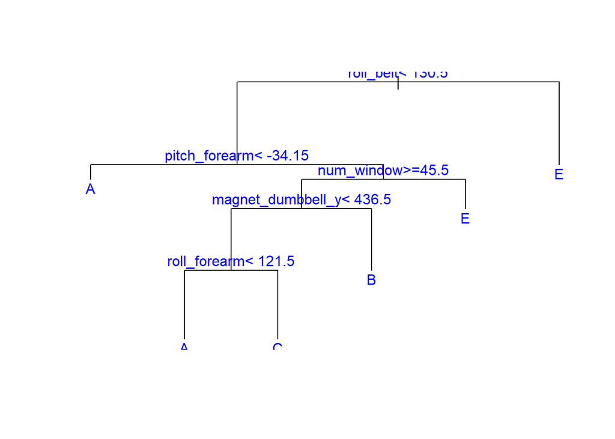

```r
plot(model_rpart$finalModel, col ="red")
text(model_rpart$finalModel, col = "blue")
```

```r
pred_rpart <- predict(model_rpart, newdata = mytesting)
confusionMatrix(mytesting$classe,pred_rpart)$overall[1]
```

```
## Accuracy
## 0.521922
```

```r
outsamplerror_rpart <- 1 - confusionMatrix(mytesting$classe,pred_rpart)$overall[1]
```

The model selection is done based on the accuracy and out of sample error. The results of the code section below indicate that Random Forest has highest accuracy and least out of sample error.

```r
# Get the model accuracy of all the models used for predictions #
confusionMatrix(mytesting$classe,pred_rf)$overall[1]
```

```
##  Accuracy
## 0.9974509
```

```r
confusionMatrix(mytesting$classe,pred_lda)$overall[1]
```

```
##  Accuracy
## 0.7072394
```

```r
confusionMatrix(mytesting$classe,pred_rpart)$overall[1]
```

```
## Accuracy
## 0.521922
```

```r
# Out of Sample Error of the models #
outsamplerror_rf
```

```
##   Accuracy
## 0.00254907
```

```r
outsamplerror_lda
```

```
##  Accuracy
## 0.2927606
```

```r
outsamplerror_rpart
```

```
## Accuracy
## 0.478078
```

Use the random forest model to predict the outcome of the validation test data to predict the 20 test cases.

```r
#~~~~~~ Predict on the validation test data based on the model with the highest accuracy ~~~~~#
pred <-  predict(model_rf, newdata = validation_data,type = "class")
pred
```

```
##  1  2  3  4  5  6  7  8  9 10 11 12 13 14 15 16 17 18 19 20
##  B  A  B  A  A  E  D  B  A  A  B  C  B  A  E  E  A  B  B  B
## Levels: A B C D E
```

The data for this project come from this source: http://web.archive.org/web/20161224072740/http:/groupware.les.inf.puc-rio.br/har.